# LESSON 5: PANDAS INTRODUCTION

[figure not shown]

## 1. Overall introduction

**pandas** is a Python package providing **fast, flexible, and expressive data structures** designed to make working with **“relational” or “labeled” data both easy and intuitive**.

**pandas** is well suited for many different kinds of data:

- **Tabular data** with heterogeneously-typed columns, as in an SQL table or Excel spreadsheet
- Ordered and unordered (not necessarily fixed-frequency) **time series data**.
- **Arbitrary matrix data** (homogeneously typed or heterogeneous) with row and column labels
- Any other form of **observational / statistical data** sets. The data need not be labeled at all to be placed into a pandas data structure

More detail about pandas can be found in this official [document](https://pandas.pydata.org/docs/user_guide/index.html).

## 2. Install and import pandas

```python
!pip install pandas
```

```python
import pandas as pd
```

## 3. Data structures in pandas

There are two main data structures in pandas: **SERIES** and **DATAFRAME**.

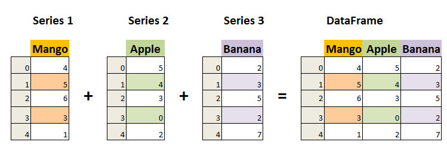

### 3.1. Series

**Series** is a one-dimensional labeled array capable of holding any data type (integers, strings, floating point numbers, Python objects, etc.).  
Checkout all arguments of pandas.Series [here](https://pandas.pydata.org/docs/reference/api/pandas.Series.html)

```python
# Init a pandas series without name
number_list = [4, 5, 6, 3, 1]
series_1 = pd.Series(data=number_list)
print(series_1, '\n', type(series_1))
```

```
0    4
1    5
2    6
3    3
4    1
dtype: int64
 <class 'pandas.core.series.Series'>
```

```python
# Init a pandas series with name
number_list = [4, 5, 6, 3, 1]
series_1 = pd.Series(data=number_list, name='Mango')
print(series_1, '\n', type(series_1))
```

```
0    4
1    5
2    6
3    3
4    1
Name: Mango, dtype: int64
 <class 'pandas.core.series.Series'>
```

```python
series_2 = pd.Series(data=[5, 4, 3, 0, 2], name='Apple')
series_3 = pd.Series(data=[2, 3, 5, 2, 7], name='Banana')

print(series_2, '\n', type(series_2))
print(series_3, '\n', type(series_3))
```

```
0    5
1    4
2    3
3    0
4    2
Name: Apple, dtype: int64
 <class 'pandas.core.series.Series'>
0    2
1    3
2    5
3    2
4    7
Name: Banana, dtype: int64
 <class 'pandas.core.series.Series'>
```

### 3.2. Dataframe

#### 3.2.1. Create dataframe from Series, list or dict

```python
# Create dataframe from ONE Series
test_df = pd.DataFrame(series_1)
print(test_df, '\n', type(test_df))
```

```
   Mango
0      4
1      5
2      6
3      3
4      1
 <class 'pandas.core.frame.DataFrame'>
```

```python
# Create dataframe from multiple Series
test_df = pd.concat([series_1, series_2, series_3], axis=1)
print(test_df, '\n', type(test_df))
```

```
   Mango  Apple  Banana
0      4      5       2
1      5      4       3
2      6      3       5
3      3      0       2
4      1      2       7
 <class 'pandas.core.frame.DataFrame'>
```

```python
# Create dataframe from dict
data_dict = {
    'Mango': [4, 5, 6, 3, 1],
    'Apple': [5, 4, 3, 0, 2],
    'Banana': [2, 3, 5, 2, 7]
}
test_df = pd.DataFrame(data_dict)
print(test_df, '\n', type(test_df))
```

```
   Mango  Apple  Banana
0      4      5       2
1      5      4       3
2      6      3       5
3      3      0       2
4      1      2       7
 <class 'pandas.core.frame.DataFrame'>
```

#### 3.2.2. Create dataframe by reading from csv or xlsx file

##### Read from CSV file

We read a csv file into pandas dataframce by using `pd.read_csv()` function. More detail about this function can be found [here](https://pandas.pydata.org/docs/reference/api/pandas.read_csv.html). Some arguments that used a lot while processing data:

- `filepath_or_buffer`
- `usecols`
- `dtype`
- `chunksize`

```python
test_df = pd.read_csv('data/predict_future_sales/items.csv')
test_df
```

|  | item_name | item_id | item_category_id |
| --- | --- | --- | --- |
| 0 | ! ВО ВЛАСТИ НАВАЖДЕНИЯ (ПЛАСТ.) D | 0 | 40 |
| 1 | !ABBYY FineReader 12 Professional Edition Full... | 1 | 76 |
| 2 | ***В ЛУЧАХ СЛАВЫ (UNV) D | 2 | 40 |
| 3 | ***ГОЛУБАЯ ВОЛНА (Univ) D | 3 | 40 |
| 4 | ***КОРОБКА (СТЕКЛО) D | 4 | 40 |
| ... | ... | ... | ... |
| 22165 | Ядерный титбит 2 [PC, Цифровая версия] | 22165 | 31 |
| 22166 | Язык запросов 1С:Предприятия [Цифровая версия] | 22166 | 54 |
| 22167 | Язык запросов 1С:Предприятия 8 (+CD). Хрустале... | 22167 | 49 |
| 22168 | Яйцо для Little Inu | 22168 | 62 |
| 22169 | Яйцо дракона (Игра престолов) | 22169 | 69 |

22170 rows × 3 columns

##### Read from XLSX file

```python
test_df = pd.read_xlsx('')
```

[output not shown]

## 4. Access element in Series and Dataframe

### 4.1. In Series

```python
print(series_1)

# Access one element
print(series_1[0])
```

```
0    4
1    5
2    6
3    3
4    1
Name: Mango, dtype: int64
4
```

```python
# Access multiple elements
print(series_1[[1, 2, 3]])
```

```
1    5
2    6
3    3
Name: Mango, dtype: int64
```

```python
# Access elements based on one condition
print(series_1[series_1 > 3])
```

```
0    4
1    5
2    6
Name: Mango, dtype: int64
```

```python
# Access elements based on multiple conditions
print(series_1[(series_1 > 3) & (series_1 < 6)])
```

```
0    4
1    5
Name: Mango, dtype: int64
```

### 4.2. In Dataframe

```python
test_df
```

|  | item_name | item_id | item_category_id |
| --- | --- | --- | --- |
| 0 | ! ВО ВЛАСТИ НАВАЖДЕНИЯ (ПЛАСТ.) D | 0 | 40 |
| 1 | !ABBYY FineReader 12 Professional Edition Full... | 1 | 76 |
| 2 | ***В ЛУЧАХ СЛАВЫ (UNV) D | 2 | 40 |
| 3 | ***ГОЛУБАЯ ВОЛНА (Univ) D | 3 | 40 |
| 4 | ***КОРОБКА (СТЕКЛО) D | 4 | 40 |
| ... | ... | ... | ... |
| 22165 | Ядерный титбит 2 [PC, Цифровая версия] | 22165 | 31 |
| 22166 | Язык запросов 1С:Предприятия [Цифровая версия] | 22166 | 54 |
| 22167 | Язык запросов 1С:Предприятия 8 (+CD). Хрустале... | 22167 | 49 |
| 22168 | Яйцо для Little Inu | 22168 | 62 |
| 22169 | Яйцо дракона (Игра престолов) | 22169 | 69 |

22170 rows × 3 columns

#### Access elements by columns

```python
# Show all columns in dataframe
test_df.columns
```

```
Index(['item_name', 'item_id', 'item_category_id'], dtype='object')
```

```python
# Access elements from one column in dataframe
test_df['item_name']
```

```
0                ! ВО ВЛАСТИ НАВАЖДЕНИЯ (ПЛАСТ.)         D
1        !ABBYY FineReader 12 Professional Edition Full...
2            ***В ЛУЧАХ СЛАВЫ   (UNV)                    D
3          ***ГОЛУБАЯ ВОЛНА  (Univ)                      D
4              ***КОРОБКА (СТЕКЛО)                       D
                               ...
22165               Ядерный титбит 2 [PC, Цифровая версия]
22166      Язык запросов 1С:Предприятия  [Цифровая версия]
22167    Язык запросов 1С:Предприятия 8 (+CD). Хрустале...
22168                                  Яйцо для Little Inu
22169                        Яйцо дракона (Игра престолов)
Name: item_name, Length: 22170, dtype: object
```

```python
# Access elements from multiple columns in dataframe
test_df[['item_id', 'item_category_id']]
```

|  | item_id | item_category_id |
| --- | --- | --- |
| 0 | 0 | 40 |
| 1 | 1 | 76 |
| 2 | 2 | 40 |
| 3 | 3 | 40 |
| 4 | 4 | 40 |
| ... | ... | ... |
| 22165 | 22165 | 31 |
| 22166 | 22166 | 54 |
| 22167 | 22167 | 49 |
| 22168 | 22168 | 62 |
| 22169 | 22169 | 69 |

22170 rows × 2 columns

#### Access elements by rows

```python
# Access a row in dataframe
test_df.loc[1]
```

```
item_name           !ABBYY FineReader 12 Professional Edition Full...
item_id                                                             1
item_category_id                                                   76
Name: 1, dtype: object
```

```python
# Access multiple rows in dataframe
test_df.loc[[1, 2, 22168]]
```

|  | item_name | item_id | item_category_id |
| --- | --- | --- | --- |
| 1 | !ABBYY FineReader 12 Professional Edition Full... | 1 | 76 |
| 2 | ***В ЛУЧАХ СЛАВЫ (UNV) D | 2 | 40 |
| 22168 | Яйцо для Little Inu | 22168 | 62 |

#### Access elements by conditions

```python
# Access elements by condition in dataframe
test_df[test_df.item_id > 1000]
```

|  | item_name | item_id | item_category_id |
| --- | --- | --- | --- |
| 1001 | 3D Action Puzzle "Зомби" Шахтер | 1001 | 67 |
| 1002 | 3D Action Puzzle "Техника" Бомбардировщик | 1002 | 67 |
| 1003 | 3D Action Puzzle "Техника" Вертолет | 1003 | 67 |
| 1004 | 3D Action Puzzle "Техника" Гоночная машинка | 1004 | 67 |
| 1005 | 3D Action Puzzle "Техника" Истребитель | 1005 | 67 |
| ... | ... | ... | ... |
| 22165 | Ядерный титбит 2 [PC, Цифровая версия] | 22165 | 31 |
| 22166 | Язык запросов 1С:Предприятия [Цифровая версия] | 22166 | 54 |
| 22167 | Язык запросов 1С:Предприятия 8 (+CD). Хрустале... | 22167 | 49 |
| 22168 | Яйцо для Little Inu | 22168 | 62 |
| 22169 | Яйцо дракона (Игра престолов) | 22169 | 69 |

21169 rows × 3 columns

```python
# Access elements by multiple conditions in dataframe
test_df[(test_df.item_id > 1000) & (test_df.item_id < 2345)]
```

|  | item_name | item_id | item_category_id |
| --- | --- | --- | --- |
| 1001 | 3D Action Puzzle "Зомби" Шахтер | 1001 | 67 |
| 1002 | 3D Action Puzzle "Техника" Бомбардировщик | 1002 | 67 |
| 1003 | 3D Action Puzzle "Техника" Вертолет | 1003 | 67 |
| 1004 | 3D Action Puzzle "Техника" Гоночная машинка | 1004 | 67 |
| 1005 | 3D Action Puzzle "Техника" Истребитель | 1005 | 67 |
| ... | ... | ... | ... |
| 2340 | Call of Juarez: Bound in Blood (Essentials) [P... | 2340 | 19 |
| 2341 | Call of Juarez: Gunslinger [PC, Jewel, русские... | 2341 | 30 |
| 2342 | Call of Juarez: Картель Limited Edition [Xbox ... | 2342 | 23 |
| 2343 | Call of Juarez: Картель [PC, Jewel, русская ве... | 2343 | 30 |
| 2344 | Call of Juarez: Картель [PC, русская версия] | 2344 | 28 |

1344 rows × 3 columns

```python
# Access elements by multiple conditions in dataframe
test_df[(test_df.item_id > 1000) & (test_df.item_id < 2345) & (test_df.item_category_id == 12)]
```

|  | item_name | item_id | item_category_id |
| --- | --- | --- | --- |

## 5. Functions with dataframe

### 5.1. Basic functions

#### Delete one row or column by `drop()`

```python
short_test_df = test_df.loc[1000:1010]
short_test_df
```

|  | item_name | item_id | item_category_id |
| --- | --- | --- | --- |
| 1000 | 3D Action Puzzle "Зомби" Уборщик | 1000 | 67 |
| 1001 | 3D Action Puzzle "Зомби" Шахтер | 1001 | 67 |
| 1002 | 3D Action Puzzle "Техника" Бомбардировщик | 1002 | 67 |
| 1003 | 3D Action Puzzle "Техника" Вертолет | 1003 | 67 |
| 1004 | 3D Action Puzzle "Техника" Гоночная машинка | 1004 | 67 |
| 1005 | 3D Action Puzzle "Техника" Истребитель | 1005 | 67 |
| 1006 | 3D Crystal Puzzle Дельфин XL | 1006 | 67 |
| 1007 | 3D Crystal Puzzle Замок XL | 1007 | 67 |
| 1008 | 3D Crystal Puzzle Заяц L | 1008 | 67 |
| 1009 | 3D Crystal Puzzle Капля L Светильник | 1009 | 67 |
| 1010 | 3D Crystal Puzzle Клубника L Светильник | 1010 | 67 |

```python
# Delete one row by index
new_df = short_test_df.drop(index=1000, axis=1)
new_df
```

|  | item_name | item_id | item_category_id |
| --- | --- | --- | --- |
| 1001 | 3D Action Puzzle "Зомби" Шахтер | 1001 | 67 |
| 1002 | 3D Action Puzzle "Техника" Бомбардировщик | 1002 | 67 |
| 1003 | 3D Action Puzzle "Техника" Вертолет | 1003 | 67 |
| 1004 | 3D Action Puzzle "Техника" Гоночная машинка | 1004 | 67 |
| 1005 | 3D Action Puzzle "Техника" Истребитель | 1005 | 67 |
| 1006 | 3D Crystal Puzzle Дельфин XL | 1006 | 67 |
| 1007 | 3D Crystal Puzzle Замок XL | 1007 | 67 |
| 1008 | 3D Crystal Puzzle Заяц L | 1008 | 67 |
| 1009 | 3D Crystal Puzzle Капля L Светильник | 1009 | 67 |
| 1010 | 3D Crystal Puzzle Клубника L Светильник | 1010 | 67 |

```python
# Delete multiple rows by index
new_df = short_test_df.drop(index=[1001, 1003, 1005, 1007, 1009], axis=1)
new_df
```

|  | item_name | item_id | item_category_id |
| --- | --- | --- | --- |
| 1000 | 3D Action Puzzle "Зомби" Уборщик | 1000 | 67 |
| 1002 | 3D Action Puzzle "Техника" Бомбардировщик | 1002 | 67 |
| 1004 | 3D Action Puzzle "Техника" Гоночная машинка | 1004 | 67 |
| 1006 | 3D Crystal Puzzle Дельфин XL | 1006 | 67 |
| 1008 | 3D Crystal Puzzle Заяц L | 1008 | 67 |
| 1010 | 3D Crystal Puzzle Клубника L Светильник | 1010 | 67 |

```python
# Delete one column by column name
new_df = short_test_df.drop(columns='item_name')
new_df
```

|  | item_id | item_category_id |
| --- | --- | --- |
| 1000 | 1000 | 67 |
| 1001 | 1001 | 67 |
| 1002 | 1002 | 67 |
| 1003 | 1003 | 67 |
| 1004 | 1004 | 67 |
| 1005 | 1005 | 67 |
| 1006 | 1006 | 67 |
| 1007 | 1007 | 67 |
| 1008 | 1008 | 67 |
| 1009 | 1009 | 67 |
| 1010 | 1010 | 67 |

```python
# Delete multiple columns by column name
new_df = short_test_df.drop(columns=['item_name', 'item_category_id'])
new_df
```

|  | item_id |
| --- | --- |
| 1000 | 1000 |
| 1001 | 1001 |
| 1002 | 1002 |
| 1003 | 1003 |
| 1004 | 1004 |
| 1005 | 1005 |
| 1006 | 1006 |
| 1007 | 1007 |
| 1008 | 1008 |
| 1009 | 1009 |
| 1010 | 1010 |

#### Drop duplicate row base on columns by `drop_duplicates()`

```python
test_df
```

|  | item_name | item_id | item_category_id |
| --- | --- | --- | --- |
| 0 | ! ВО ВЛАСТИ НАВАЖДЕНИЯ (ПЛАСТ.) D | 0 | 40 |
| 1 | !ABBYY FineReader 12 Professional Edition Full... | 1 | 76 |
| 2 | ***В ЛУЧАХ СЛАВЫ (UNV) D | 2 | 40 |
| 3 | ***ГОЛУБАЯ ВОЛНА (Univ) D | 3 | 40 |
| 4 | ***КОРОБКА (СТЕКЛО) D | 4 | 40 |
| ... | ... | ... | ... |
| 22165 | Ядерный титбит 2 [PC, Цифровая версия] | 22165 | 31 |
| 22166 | Язык запросов 1С:Предприятия [Цифровая версия] | 22166 | 54 |
| 22167 | Язык запросов 1С:Предприятия 8 (+CD). Хрустале... | 22167 | 49 |
| 22168 | Яйцо для Little Inu | 22168 | 62 |
| 22169 | Яйцо дракона (Игра престолов) | 22169 | 69 |

22170 rows × 3 columns

```python
test_df.drop_duplicates(subset='item_category_id')
```

|  | item_name | item_id | item_category_id |
| --- | --- | --- | --- |
| 0 | ! ВО ВЛАСТИ НАВАЖДЕНИЯ (ПЛАСТ.) D | 0 | 40 |
| 1 | !ABBYY FineReader 12 Professional Edition Full... | 1 | 76 |
| 12 | *МИХЕЙ И ДЖУМАНДЖИ Сука любовь | 12 | 55 |
| 27 | 007 Legends [PS3, русская версия] | 27 | 19 |
| 28 | 007 Legends [PС, Jewel, русская версия] | 28 | 30 |
| ... | ... | ... | ... |
| 16834 | Открытка Лакарт КОД 5 (в ассортименте) | 16834 | 50 |
| 17703 | Правила дорожного движения 2009. Новейшая мето... | 17703 | 51 |
| 17717 | Прием денежных средств для 1С-Онлайн | 17717 | 79 |
| 19700 | ТОЛСТАЯ Е. Адмиралъ | 19700 | 53 |
| 22085 | Элемент питания DURACELL 123 A Ultra MP3 1*BL | 22085 | 83 |

84 rows × 3 columns

#### Process NULL value by `dropna()` and `fillna()`

```python
import numpy as np

nan_df = pd.DataFrame(data={
    'name': ['Minh', np.nan, 'Hieu'],
    'age': [24, 30, None],
    'job': ['DS', 'DA', 'DE']
})
nan_df
```

|  | name | age | job |
| --- | --- | --- | --- |
| 0 | Minh | 24.0 | DS |
| 1 | NaN | 30.0 | DA |
| 2 | Hieu | NaN | DE |

```python
# Drop nan values by row
new_df = nan_df.dropna(axis=0)
new_df
```

|  | name | age | job |
| --- | --- | --- | --- |
| 0 | Minh | 24.0 | DS |

```python
# Drop nan values by columns
new_df = nan_df.dropna(axis=1)
new_df
```

|  | job |
| --- | --- |
| 0 | DS |
| 1 | DA |
| 2 | DE |

```python
# Fill all nan values with one specific value
new_df = nan_df.fillna(-1)
new_df
```

|  | name | age | job |
| --- | --- | --- | --- |
| 0 | Minh | 24.0 | DS |
| 1 | -1 | 30.0 | DA |
| 2 | Hieu | -1.0 | DE |

```python
# Fill nan values according to columns
new_df = nan_df.fillna({
    'name': 'Thao Anh',
    'age': -99,
    'job': 'student'
})
new_df
```

|  | name | age | job |
| --- | --- | --- | --- |
| 0 | Minh | 24.0 | DS |
| 1 | Thao Anh | 30.0 | DA |
| 2 | Hieu | -99.0 | DE |

#### Modify elements in dataframe by `apply()`

```python
short_test_df
```

|  | item_name | item_id | item_category_id |
| --- | --- | --- | --- |
| 1000 | 3D Action Puzzle "Зомби" Уборщик | 1000 | 67 |
| 1001 | 3D Action Puzzle "Зомби" Шахтер | 1001 | 67 |
| 1002 | 3D Action Puzzle "Техника" Бомбардировщик | 1002 | 67 |
| 1003 | 3D Action Puzzle "Техника" Вертолет | 1003 | 67 |
| 1004 | 3D Action Puzzle "Техника" Гоночная машинка | 1004 | 67 |
| 1005 | 3D Action Puzzle "Техника" Истребитель | 1005 | 67 |
| 1006 | 3D Crystal Puzzle Дельфин XL | 1006 | 67 |
| 1007 | 3D Crystal Puzzle Замок XL | 1007 | 67 |
| 1008 | 3D Crystal Puzzle Заяц L | 1008 | 67 |
| 1009 | 3D Crystal Puzzle Капля L Светильник | 1009 | 67 |
| 1010 | 3D Crystal Puzzle Клубника L Светильник | 1010 | 67 |

```python
short_test_df.item_category_id = short_test_df.item_category_id.apply(float)
short_test_df
```

|  | item_name | item_id | item_category_id |
| --- | --- | --- | --- |
| 1000 | 3D Action Puzzle "Зомби" Уборщик | 1000 | 67.0 |
| 1001 | 3D Action Puzzle "Зомби" Шахтер | 1001 | 67.0 |
| 1002 | 3D Action Puzzle "Техника" Бомбардировщик | 1002 | 67.0 |
| 1003 | 3D Action Puzzle "Техника" Вертолет | 1003 | 67.0 |
| 1004 | 3D Action Puzzle "Техника" Гоночная машинка | 1004 | 67.0 |
| 1005 | 3D Action Puzzle "Техника" Истребитель | 1005 | 67.0 |
| 1006 | 3D Crystal Puzzle Дельфин XL | 1006 | 67.0 |
| 1007 | 3D Crystal Puzzle Замок XL | 1007 | 67.0 |
| 1008 | 3D Crystal Puzzle Заяц L | 1008 | 67.0 |
| 1009 | 3D Crystal Puzzle Капля L Светильник | 1009 | 67.0 |
| 1010 | 3D Crystal Puzzle Клубника L Светильник | 1010 | 67.0 |

```python
short_test_df.item_category_id = short_test_df.item_category_id.apply(lambda x: (x + 1) / 2)
short_test_df
```

|  | item_name | item_id | item_category_id |
| --- | --- | --- | --- |
| 1000 | 3D Action Puzzle "Зомби" Уборщик | 1000 | 34.0 |
| 1001 | 3D Action Puzzle "Зомби" Шахтер | 1001 | 34.0 |
| 1002 | 3D Action Puzzle "Техника" Бомбардировщик | 1002 | 34.0 |
| 1003 | 3D Action Puzzle "Техника" Вертолет | 1003 | 34.0 |
| 1004 | 3D Action Puzzle "Техника" Гоночная машинка | 1004 | 34.0 |
| 1005 | 3D Action Puzzle "Техника" Истребитель | 1005 | 34.0 |
| 1006 | 3D Crystal Puzzle Дельфин XL | 1006 | 34.0 |
| 1007 | 3D Crystal Puzzle Замок XL | 1007 | 34.0 |
| 1008 | 3D Crystal Puzzle Заяц L | 1008 | 34.0 |
| 1009 | 3D Crystal Puzzle Капля L Светильник | 1009 | 34.0 |
| 1010 | 3D Crystal Puzzle Клубника L Светильник | 1010 | 34.0 |

```python
def plus_1_divide_2(x):
    return (x + 1) / 2

short_test_df.item_category_id = short_test_df.item_category_id.apply(plus_1_divide_2)
short_test_df
```

|  | item_name | item_id | item_category_id |
| --- | --- | --- | --- |
| 1000 | 3D Action Puzzle "Зомби" Уборщик | 1000 | 17.5 |
| 1001 | 3D Action Puzzle "Зомби" Шахтер | 1001 | 17.5 |
| 1002 | 3D Action Puzzle "Техника" Бомбардировщик | 1002 | 17.5 |
| 1003 | 3D Action Puzzle "Техника" Вертолет | 1003 | 17.5 |
| 1004 | 3D Action Puzzle "Техника" Гоночная машинка | 1004 | 17.5 |
| 1005 | 3D Action Puzzle "Техника" Истребитель | 1005 | 17.5 |
| 1006 | 3D Crystal Puzzle Дельфин XL | 1006 | 17.5 |
| 1007 | 3D Crystal Puzzle Замок XL | 1007 | 17.5 |
| 1008 | 3D Crystal Puzzle Заяц L | 1008 | 17.5 |
| 1009 | 3D Crystal Puzzle Капля L Светильник | 1009 | 17.5 |
| 1010 | 3D Crystal Puzzle Клубника L Светильник | 1010 | 17.5 |

#### Save a dataframe to csv file by using `to_csv()`

```python
short_test_df.to_csv('short_test_df.csv', index=False)
```

### 5.2. Advanced functions

```python
test_df
```

|  | item_name | item_id | item_category_id |
| --- | --- | --- | --- |
| 0 | ! ВО ВЛАСТИ НАВАЖДЕНИЯ (ПЛАСТ.) D | 0 | 40 |
| 1 | !ABBYY FineReader 12 Professional Edition Full... | 1 | 76 |
| 2 | ***В ЛУЧАХ СЛАВЫ (UNV) D | 2 | 40 |
| 3 | ***ГОЛУБАЯ ВОЛНА (Univ) D | 3 | 40 |
| 4 | ***КОРОБКА (СТЕКЛО) D | 4 | 40 |
| ... | ... | ... | ... |
| 22165 | Ядерный титбит 2 [PC, Цифровая версия] | 22165 | 31 |
| 22166 | Язык запросов 1С:Предприятия [Цифровая версия] | 22166 | 54 |
| 22167 | Язык запросов 1С:Предприятия 8 (+CD). Хрустале... | 22167 | 49 |
| 22168 | Яйцо для Little Inu | 22168 | 62 |
| 22169 | Яйцо дракона (Игра престолов) | 22169 | 69 |

22170 rows × 3 columns

#### Aggregate data by `groupby()` and `agg()`

```python
new_df = test_df.groupby(by='item_category_id')
new_df
```

```
<pandas.core.groupby.generic.DataFrameGroupBy object at 0x117bf80a0>
```

```python
new_df = new_df.agg({'item_name': list, 'item_id': list})
new_df
```

| item_category_id | item_name | item_id |
| --- | --- | --- |
| 0 | [PC: Гарнитура HyperX Cloud Core игровая стере... | [5441, 16255, 16256, 16257] |
| 1 | [PS2: Карта памяти 8 Мб черная (Memory Card 8M... | [5606, 5740] |
| 2 | [PS Move Controller (Контроллер движений), PS ... | [5570, 5571, 5572, 5573, 5574, 5575, 5576, 560... |
| 3 | [PS4/PS3: Гарнитура Tritton Kunai стерео прово... | [5652, 5653, 5654, 5655, 5656, 5657, 5658, 565... |
| 4 | [Black Horns PSP Slim Джинсовый чехол серый (B... | [1955, 1956, 1957, 1958, 3111, 3666, 3667, 366... |
| ... | ... | ... |
| 79 | [Прием денежных средств для 1С-Онлайн] | [17717] |
| 80 | [Билет "ИгроМир 2015" - 2 октября 2015 (сайт) ... | [9244, 9246, 9248, 9250, 9252, 9254] |
| 81 | [Компактдиск Mirex CD-R printable inkjet 48x C... | [13346, 13347, 13349, 13352, 13355, 13356, 13358] |
| 82 | [Компактдиск Mirex CD-R 700 Мб 48x Slim case P... | [13344, 13345, 13348, 13350, 13351, 13353, 133... |
| 83 | [Элемент питания DURACELL 123 A Ultra MP3 1*BL... | [22085, 22086, 22087, 22088, 22089, 22090, 220... |

84 rows × 2 columns

```python
new_df = new_df.reset_index()
new_df
```

|  | item_category_id | item_name | item_id |
| --- | --- | --- | --- |
| 0 | 0 | [PC: Гарнитура HyperX Cloud Core игровая стере... | [5441, 16255, 16256, 16257] |
| 1 | 1 | [PS2: Карта памяти 8 Мб черная (Memory Card 8M... | [5606, 5740] |
| 2 | 2 | [PS Move Controller (Контроллер движений), PS ... | [5570, 5571, 5572, 5573, 5574, 5575, 5576, 560... |
| 3 | 3 | [PS4/PS3: Гарнитура Tritton Kunai стерео прово... | [5652, 5653, 5654, 5655, 5656, 5657, 5658, 565... |
| 4 | 4 | [Black Horns PSP Slim Джинсовый чехол серый (B... | [1955, 1956, 1957, 1958, 3111, 3666, 3667, 366... |
| ... | ... | ... | ... |
| 79 | 79 | [Прием денежных средств для 1С-Онлайн] | [17717] |
| 80 | 80 | [Билет "ИгроМир 2015" - 2 октября 2015 (сайт) ... | [9244, 9246, 9248, 9250, 9252, 9254] |
| 81 | 81 | [Компактдиск Mirex CD-R printable inkjet 48x C... | [13346, 13347, 13349, 13352, 13355, 13356, 13358] |
| 82 | 82 | [Компактдиск Mirex CD-R 700 Мб 48x Slim case P... | [13344, 13345, 13348, 13350, 13351, 13353, 133... |
| 83 | 83 | [Элемент питания DURACELL 123 A Ultra MP3 1*BL... | [22085, 22086, 22087, 22088, 22089, 22090, 220... |

84 rows × 3 columns

#### Join two dataframes by using `pd.merge()`

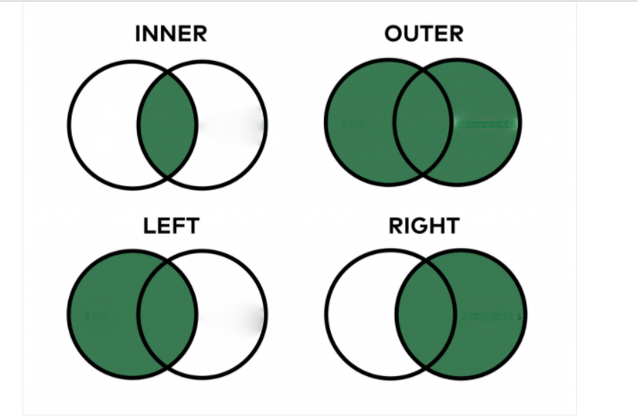

```python
# Create dummy dataframe
# index % 2 == 0
dummy_1_df = test_df.loc[list(range(0, len(test_df) - 1, 2))]
dummy_1_df
```

|  | item_name | item_id | item_category_id |
| --- | --- | --- | --- |
| 0 | ! ВО ВЛАСТИ НАВАЖДЕНИЯ (ПЛАСТ.) D | 0 | 40 |
| 2 | ***В ЛУЧАХ СЛАВЫ (UNV) D | 2 | 40 |
| 4 | ***КОРОБКА (СТЕКЛО) D | 4 | 40 |
| 6 | ***УДАР ПО ВОРОТАМ (UNI) D | 6 | 40 |
| 8 | ***ЧАЙ С МУССОЛИНИ D | 8 | 40 |
| ... | ... | ... | ... |
| 22160 | ЯРМАРКА ТЩЕСЛАВИЯ (Регион) | 22160 | 40 |
| 22162 | ЯРОСТЬ | 22162 | 40 |
| 22164 | ЯРОСТЬ (BD) | 22164 | 37 |
| 22166 | Язык запросов 1С:Предприятия [Цифровая версия] | 22166 | 54 |
| 22168 | Яйцо для Little Inu | 22168 | 62 |

11085 rows × 3 columns

```python
# Create dummy dataframe
# index % 3 == 0
dummy_2_df = test_df.loc[list(range(0, len(test_df) - 1, 3))]
dummy_2_df
```

|  | item_name | item_id | item_category_id |
| --- | --- | --- | --- |
| 0 | ! ВО ВЛАСТИ НАВАЖДЕНИЯ (ПЛАСТ.) D | 0 | 40 |
| 3 | ***ГОЛУБАЯ ВОЛНА (Univ) D | 3 | 40 |
| 6 | ***УДАР ПО ВОРОТАМ (UNI) D | 6 | 40 |
| 9 | ***ШУГАРЛЭНДСКИЙ ЭКСПРЕСС (UNI) D | 9 | 40 |
| 12 | *МИХЕЙ И ДЖУМАНДЖИ Сука любовь | 12 | 55 |
| ... | ... | ... | ... |
| 22155 | ЯДЫ, ИЛИ ВСЕМИРНАЯ ИСТОРИЯ ОТРАВЛЕНИЙ (BD) | 22155 | 37 |
| 22158 | ЯМА (rem) | 22158 | 40 |
| 22161 | ЯРОСЛАВ. ТЫСЯЧУ ЛЕТ НАЗАД э (BD) | 22161 | 37 |
| 22164 | ЯРОСТЬ (BD) | 22164 | 37 |
| 22167 | Язык запросов 1С:Предприятия 8 (+CD). Хрустале... | 22167 | 49 |

7390 rows × 3 columns

```python
merged_df = pd.merge(dummy_1_df, dummy_2_df, how='inner', on='item_id')
merged_df
```

|  | item_name_x | item_id | item_category_id_x | item_name_y | item_category_id_y |
| --- | --- | --- | --- | --- | --- |
| 0 | ! ВО ВЛАСТИ НАВАЖДЕНИЯ (ПЛАСТ.) D | 0 | 40 | ! ВО ВЛАСТИ НАВАЖДЕНИЯ (ПЛАСТ.) D | 40 |
| 1 | ***УДАР ПО ВОРОТАМ (UNI) D | 6 | 40 | ***УДАР ПО ВОРОТАМ (UNI) D | 40 |
| 2 | *МИХЕЙ И ДЖУМАНДЖИ Сука любовь | 12 | 55 | *МИХЕЙ И ДЖУМАНДЖИ Сука любовь | 55 |
| 3 | /БОМБА ДЛЯ НЕВЕСТЫ /2DVD/ D | 18 | 40 | /БОМБА ДЛЯ НЕВЕСТЫ /2DVD/ D | 40 |
| 4 | /СМЕРТЕЛЬНЫЙ РАСКЛАД | 24 | 40 | /СМЕРТЕЛЬНЫЙ РАСКЛАД | 40 |
| ... | ... | ... | ... | ... | ... |
| 3690 | Я, РОБОТ (BD) | 22140 | 37 | Я, РОБОТ (BD) | 37 |
| 3691 | Я-ЛЕГЕНДА WB (BD) | 22146 | 37 | Я-ЛЕГЕНДА WB (BD) | 37 |
| 3692 | ЯВЛЕНИЕ (2012) (регион) | 22152 | 40 | ЯВЛЕНИЕ (2012) (регион) | 40 |
| 3693 | ЯМА (rem) | 22158 | 40 | ЯМА (rem) | 40 |
| 3694 | ЯРОСТЬ (BD) | 22164 | 37 | ЯРОСТЬ (BD) | 37 |

3695 rows × 5 columns

## 6. Homework

1. Create dummy dataset which contains 5 data fields: "first_name", "last_name", "age", "job", "country" and 10 rows. (dataset contains 1 "country" named "Vietnam", 1 age is "20")
2. Create 5 Series for each field, after that, create a Dataframe from 5 Series, dump that Dataframe to csv file.
3. Read the csv file from excercise 2, add the string "my_first_name" in to each value in the "first_name", add the string "my_last_name" in to each value in the "last_name".
4. Print all rows whose "country" is "Vietnam", whose "country" is not "Vietnam", whose "age" is greater than "20", whose "age" is lower than or equal "20".